# Practical machine learning assignment

Kimberly Hermans

April 24, 2016

# The assignment

One thing that people regularly do is quantify how much of a particular activity they do, but they rarely quantify how well they do it. In this project, the goal will be to use data from accelerometers on the belt, forearm, arm, and dumbell of 6 participants.

```r
#Load the required packages
library(caret)
library(rattle)
#Read in the data
masterdata <- read.csv("C:/Users/Kihr/Downloads/pml-training (1).csv", na.strings = c("", "NA", "NULL", " "))
validationSet <- read.csv("C:/Users/Kihr/Downloads/pml-testing.csv", na.strings = c("", "NA", "NULL", " "))

#view the summary of each column
summary(masterdata)
```

[output not shown]

[output cut: 313 more lines]

[output not shown]

# Data quality

In this part we will review the data quality. Looking at the summary of the data, we see that if there are missing values, there are too many. We will therefor remove all columns which show one or more missing values. Furthermore there are unrelevant collumns, highly correlated variables and variables which have no or very little variance. This last part didn’t result in any variable drops.

```r
#Remove columns with too much NA values
masterdata <- masterdata[ , colSums(is.na(masterdata)) == 0]

#Remove irrelevant variables and variables with too little variance
irrelevant <- c('X', 'user_name', 'raw_timestamp_part_1', 'raw_timestamp_part_2', 'cvtd_timestamp', 'new_window', 'num_window')
masterdata <- masterdata[, -which(names(masterdata) %in% irrelevant)]

littleVar <- nearZeroVar(masterdata[sapply(masterdata, is.numeric)], saveMetrics = TRUE)
masterdata <- masterdata[,littleVar[, 'nzv']==0]

#check correlation between variables too exclude too high correlations (remove correlation over 0.8)
corrMatrix <- cor(na.omit(masterdata[sapply(masterdata, is.numeric)]))

highCor = findCorrelation(corrMatrix, cutoff = .80, verbose = TRUE)
```

```
## Compare row 10  and column  1 with corr  0.992
##   Means:  0.27 vs 0.168 so flagging column 10
## Compare row 1  and column  9 with corr  0.925
##   Means:  0.25 vs 0.164 so flagging column 1
## Compare row 9  and column  4 with corr  0.928
##   Means:  0.233 vs 0.161 so flagging column 9
## Compare row 36  and column  29 with corr  0.849
##   Means:  0.251 vs 0.158 so flagging column 36
## Compare row 8  and column  2 with corr  0.966
##   Means:  0.239 vs 0.154 so flagging column 8
## Compare row 2  and column  11 with corr  0.884
##   Means:  0.221 vs 0.15 so flagging column 2
## Compare row 21  and column  24 with corr  0.814
##   Means:  0.194 vs 0.149 so flagging column 21
## Compare row 34  and column  28 with corr  0.808
##   Means:  0.185 vs 0.146 so flagging column 34
## Compare row 25  and column  26 with corr  0.814
##   Means:  0.154 vs 0.145 so flagging column 25
## Compare row 19  and column  18 with corr  0.918
##   Means:  0.096 vs 0.146 so flagging column 18
## Compare row 46  and column  45 with corr  0.846
##   Means:  0.11 vs 0.149 so flagging column 45
## Compare row 46  and column  31 with corr  0.914
##   Means:  0.091 vs 0.152 so flagging column 31
## Compare row 46  and column  33 with corr  0.933
##   Means:  0.07 vs 0.156 so flagging column 33
## All correlations <= 0.8
```

```r
masterdata = masterdata[,-highCor]
```

Our modelset now contains only 40 variables and 19622 cases.

# Modelling

We will split up the data into a train and testset, to test our created model(s). The split was done based on the target variable, 65% in train and 35% in test.

```r
#Split train and testset
inTrain <- createDataPartition(y=masterdata$classe, p=0.65, list=FALSE)
trainSet <- masterdata[inTrain,]
testSet <- masterdata[-inTrain,]
```

## Decision tree

```r
#Creating decision tree with caret package and visualise it with rattle
modFit <- train(classe ~ .,method="rpart",data=trainSet)
print(modFit$finalModel)
```

```
## n= 12757
##
## node), split, n, loss, yval, (yprob)
##       * denotes terminal node
##
##  1) root 12757 9130 A (0.28 0.19 0.17 0.16 0.18)
##    2) pitch_forearm< -33.95 1040    3 A (1 0.0029 0 0 0) *
##    3) pitch_forearm>=-33.95 11717 9127 A (0.22 0.21 0.19 0.18 0.2)
##      6) magnet_belt_y>=555.5 10746 8159 A (0.24 0.23 0.21 0.18 0.15)
##       12) magnet_dumbbell_y< 426.5 8871 6357 A (0.28 0.18 0.24 0.17 0.12)
##         24) roll_forearm< 121.5 5559 3298 A (0.41 0.18 0.18 0.14 0.089) *
##         25) roll_forearm>=121.5 3312 2191 C (0.076 0.18 0.34 0.22 0.18)
##           50) accel_forearm_x>=-103.5 2297 1413 C (0.088 0.22 0.38 0.091 0.22) *
##           51) accel_forearm_x< -103.5 1015  483 D (0.051 0.091 0.23 0.52 0.1) *
##       13) magnet_dumbbell_y>=426.5 1875 1014 B (0.039 0.46 0.046 0.2 0.25) *
##      7) magnet_belt_y< 555.5 971  192 E (0.0031 0.0031 0.001 0.19 0.8) *
```

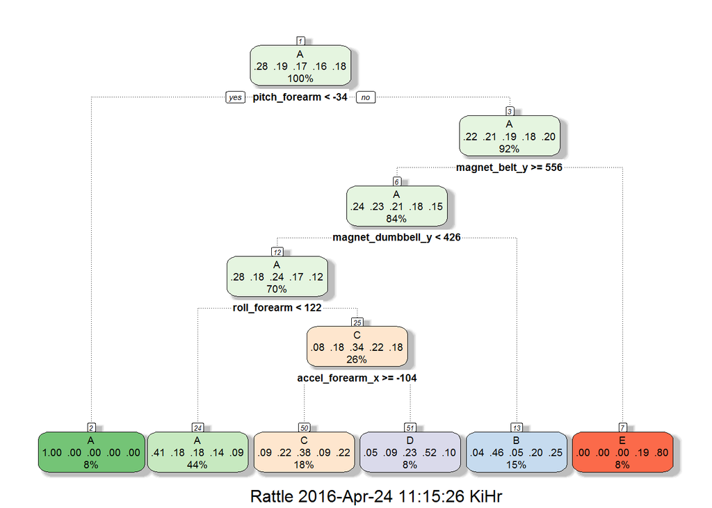

```r
fancyRpartPlot(modFit$finalModel)
```

Now we have the model, we will validate it via cross-validation:

```r
#use model to predict cases of the testset
predTest.tree=predict(modFit,testSet)
predMatrix = with(testSet,table(predTest.tree,classe))

#Compute the error rate
sum(diag(predMatrix))/sum(as.vector(predMatrix))
```

```
## [1] 0.4938092
```

This model is not sufficient enough as the accuracy is not even 50%

## Random forest

The random forest algorithm usually performs very accurate, on the other hand we will have to watch out for overfitting. Unfortunately random forests do take a long(er) time to run

```r
#Create random forest with caret package
modFitRf <- train(classe ~ .,method="rf",data=trainSet, ntree=100)
print(modFitRf$finalModel)
```

```
##
## Call:
##  randomForest(x = x, y = y, ntree = 100, mtry = param$mtry)
##                Type of random forest: classification
##                      Number of trees: 100
## No. of variables tried at each split: 20
##
##         OOB estimate of  error rate: 0.97%
## Confusion matrix:
##      A    B    C    D    E class.error
## A 3621    5    0    0    1 0.001654260
## B   23 2426   18    1    1 0.017415958
## C    0   19 2192   14    0 0.014831461
## D    3    0   29 2058    1 0.015781923
## E    0    0    3    6 2336 0.003837953
```

```r
#use model to predict cases of the testset
predTest.rf=predict(modFitRf,testSet)

#Compute error rat
predMatrix = with(testSet,table(predTest.rf,classe))
sum(diag(predMatrix))/sum(as.vector(predMatrix))
```

```
## [1] 0.9892207
```

As you can see these results are much better and can seen as a proper model. This model with accuracy of 99% will be used to predict the 20 cases in the validation set that have to be admitted in Coursera.